# Practica Fundamentos Casas

Natalia Alonso, Beatriz Martín y Susana Albarran

2/12/2019

# Introducción

Los datos que se van a analizar en este proyecto han sido obtenidos desde Kaggle. contienen precios de casas que fueron vendidas desde Mayo de 2014 hasta Mayo de 2015 en **King County** es un condado ubicado en el estado estadounidense de Washington.

Se van a seguir los siguientes pasos:

- Objetivo del estudio.
- Descripción de los datos.
- Análisis exploratorio de los datos.(Univariante)
- Transformación de variables cuantitativas.
- Procesado de variables cualitativas.
- Detección, tratamiento e imputación de datos faltantes.
- Train and Test.
- Aplicación de un modelo.

# Objetivo del estudio

Lo que queremos hacer con estos datos es crear un modelo para poder predecir los precios de las casas en King County , basándose en las variables que se incluyen en el dataset con el que se va a trabajar.

# Descripción de los datos

Los datos con los que se van a trabajar han sido extraidos de Kaggle: https://www.kaggle.com/harlfoxem/housesalesprediction

A continuación se van a describir las variables:

**1.- Id**: Es un identificador para cada casa que se ha vendido.

**2.- Date**: Fecha de venta de la casa.

**3.- Price**: Precio de venta de la casa.

**4.- Bedrooms**: Núnero de habitaciones que tiene la casa.

**5.- Bathrooms**: Número de cuartos de baño.Es importante destacar que 0.5 cuenta como baño que tiene ducha y no bañera.

**6.- sqft_living**: pies cuadrados habitables.

**7.- sqft_lot**: pies cuadrados del exterior de la casa.

**8.- Floors**: Número de plantas, hay que tener en cuenta que se contabiliza 0.5 plantas cuando una planta no tiene todo el espacio construido.  
Ejemplo: Buhardilla.

**9.- Waterfront**: Vistas al agua.Es una variable Dummy que nos dice si las casas tienen o no vistas al agua.

**10.- View**: Vistas de la casa. Es una variable que toma valores de 0 a 4.

**11.- Condition**: Condiciones de la casa. Toma valores de 1 a 5.

**12.- Grade**: grados de calidad en la construccion. Toma valores de 1 a 13.

**13.- Conditions**: condiciones la casa. Toma valores de 1 a 5.

**14.- sqft_above**: Pies cuadrados por encima del suelo.

**15.- sqft_basement**: Pies cuadrados del sótano.

**16.- yr_built**: Año de construcción.

**17.- yr_renovated**: Año en el que la casa se ha realizado *

**18.- Zipcode**: En qué área se encuentra la casa.

**19.- lat**: Latitud.

**20.- long**: Longitud

**21.- sqft_living15**: Pies cuadrados del interior de las 15 casas más cercanas.

**22.- sqft_lot15**: Pies cuadrados del exterior de las 15 casas más cercanas.

A continuación, se van a cargar los datos en R:

Visualizamos una muestra de los datos:

```r
head(datos)
```

```
##           id            date   price bedrooms bathrooms sqft_living
## 1 7129300520 20141013T000000  221900        3      1.00        1180
## 2 6414100192 20141209T000000  538000        3      2.25        2570
## 3 5631500400 20150225T000000  180000        2      1.00         770
## 4 2487200875 20141209T000000  604000        4      3.00        1960
## 5 1954400510 20150218T000000  510000        3      2.00        1680
## 6 7237550310 20140512T000000 1225000        4      4.50        5420
##   sqft_lot floors waterfront view condition grade sqft_above sqft_basement
## 1     5650      1          0    0         3     7       1180             0
## 2     7242      2          0    0         3     7       2170           400
## 3    10000      1          0    0         3     6        770             0
## 4     5000      1          0    0         5     7       1050           910
## 5     8080      1          0    0         3     8       1680             0
## 6   101930      1          0    0         3    11       3890          1530
##   yr_built yr_renovated zipcode     lat     long sqft_living15 sqft_lot15
## 1     1955            0   98178 47.5112 -122.257          1340       5650
## 2     1951         1991   98125 47.7210 -122.319          1690       7639
## 3     1933            0   98028 47.7379 -122.233          2720       8062
## 4     1965            0   98136 47.5208 -122.393          1360       5000
## 5     1987            0   98074 47.6168 -122.045          1800       7503
## 6     2001            0   98053 47.6561 -122.005          4760     101930
```

## Análisis exploratorio de datos (Univariante)

Se muestra un resumen de los datos con los que se va a trabajar: :

```r
str(datos)
```

```
## 'data.frame':    21613 obs. of  21 variables:
##  $ id           : num  7.13e+09 6.41e+09 5.63e+09 2.49e+09 1.95e+09 ...
##  $ date         : Factor w/ 372 levels "20140502T000000",..: 165 221 291 221 284 11 57 252 340 306 ...
##  $ price        : num  221900 538000 180000 604000 510000 ...
##  $ bedrooms     : int  3 3 2 4 3 4 3 3 3 3 ...
##  $ bathrooms    : num  1 2.25 1 3 2 4.5 2.25 1.5 1 2.5 ...
##  $ sqft_living  : int  1180 2570 770 1960 1680 5420 1715 1060 1780 1890 ...
##  $ sqft_lot     : int  5650 7242 10000 5000 8080 101930 6819 9711 7470 6560 ...
##  $ floors       : num  1 2 1 1 1 1 2 1 1 2 ...
##  $ waterfront   : int  0 0 0 0 0 0 0 0 0 0 ...
##  $ view         : int  0 0 0 0 0 0 0 0 0 0 ...
##  $ condition    : int  3 3 3 5 3 3 3 3 3 3 ...
##  $ grade        : int  7 7 6 7 8 11 7 7 7 7 ...
##  $ sqft_above   : int  1180 2170 770 1050 1680 3890 1715 1060 1050 1890 ...
##  $ sqft_basement: int  0 400 0 910 0 1530 0 0 730 0 ...
##  $ yr_built     : int  1955 1951 1933 1965 1987 2001 1995 1963 1960 2003 ...
##  $ yr_renovated : int  0 1991 0 0 0 0 0 0 0 0 ...
##  $ zipcode      : int  98178 98125 98028 98136 98074 98053 98003 98198 98146 98038 ...
##  $ lat          : num  47.5 47.7 47.7 47.5 47.6 ...
##  $ long         : num  -122 -122 -122 -122 -122 ...
##  $ sqft_living15: int  1340 1690 2720 1360 1800 4760 2238 1650 1780 2390 ...
##  $ sqft_lot15   : int  5650 7639 8062 5000 7503 101930 6819 9711 8113 7570 ...
```

```r
summary(datos)
```

```
##        id                         date           price
##  Min.   :1.000e+06   20140623T000000:  142   Min.   :  75000
##  1st Qu.:2.123e+09   20140625T000000:  131   1st Qu.: 321950
##  Median :3.905e+09   20140626T000000:  131   Median : 450000
##  Mean   :4.580e+09   20140708T000000:  127   Mean   : 540088
##  3rd Qu.:7.309e+09   20150427T000000:  126   3rd Qu.: 645000
##  Max.   :9.900e+09   20150325T000000:  123   Max.   :7700000
##                      (Other)        :20833
##     bedrooms        bathrooms      sqft_living       sqft_lot
##  Min.   : 0.000   Min.   :0.000   Min.   :  290   Min.   :    520
##  1st Qu.: 3.000   1st Qu.:1.750   1st Qu.: 1427   1st Qu.:   5040
##  Median : 3.000   Median :2.250   Median : 1910   Median :   7618
##  Mean   : 3.371   Mean   :2.115   Mean   : 2080   Mean   :  15107
##  3rd Qu.: 4.000   3rd Qu.:2.500   3rd Qu.: 2550   3rd Qu.:  10688
##  Max.   :33.000   Max.   :8.000   Max.   :13540   Max.   :1651359
##
##      floors        waterfront            view          condition
##  Min.   :1.000   Min.   :0.000000   Min.   :0.0000   Min.   :1.000
##  1st Qu.:1.000   1st Qu.:0.000000   1st Qu.:0.0000   1st Qu.:3.000
##  Median :1.500   Median :0.000000   Median :0.0000   Median :3.000
##  Mean   :1.494   Mean   :0.007542   Mean   :0.2343   Mean   :3.409
##  3rd Qu.:2.000   3rd Qu.:0.000000   3rd Qu.:0.0000   3rd Qu.:4.000
##  Max.   :3.500   Max.   :1.000000   Max.   :4.0000   Max.   :5.000
##
##      grade          sqft_above   sqft_basement       yr_built
##  Min.   : 1.000   Min.   : 290   Min.   :   0.0   Min.   :1900
##  1st Qu.: 7.000   1st Qu.:1190   1st Qu.:   0.0   1st Qu.:1951
##  Median : 7.000   Median :1560   Median :   0.0   Median :1975
##  Mean   : 7.657   Mean   :1788   Mean   : 291.5   Mean   :1971
##  3rd Qu.: 8.000   3rd Qu.:2210   3rd Qu.: 560.0   3rd Qu.:1997
##  Max.   :13.000   Max.   :9410   Max.   :4820.0   Max.   :2015
##
##   yr_renovated       zipcode           lat             long
##  Min.   :   0.0   Min.   :98001   Min.   :47.16   Min.   :-122.5
##  1st Qu.:   0.0   1st Qu.:98033   1st Qu.:47.47   1st Qu.:-122.3
##  Median :   0.0   Median :98065   Median :47.57   Median :-122.2
##  Mean   :  84.4   Mean   :98078   Mean   :47.56   Mean   :-122.2
##  3rd Qu.:   0.0   3rd Qu.:98118   3rd Qu.:47.68   3rd Qu.:-122.1
##  Max.   :2015.0   Max.   :98199   Max.   :47.78   Max.   :-121.3
##
##  sqft_living15    sqft_lot15
##  Min.   : 399   Min.   :   651
##  1st Qu.:1490   1st Qu.:  5100
##  Median :1840   Median :  7620
##  Mean   :1987   Mean   : 12768
##  3rd Qu.:2360   3rd Qu.: 10083
##  Max.   :6210   Max.   :871200
##
```

A continuación, se va a realizar un **estudio univariante** para ver como se comporta cada variable:

**-Variable Price**: es numérica, se va a pintar un histograma y la densidad para ver su comportamiento.

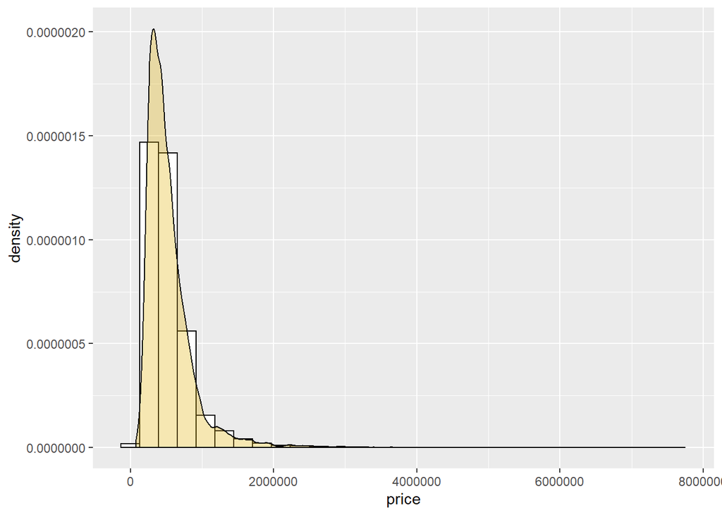

```r
options(scipen=999)
options(repr.plot.width=6, repr.plot.height=3,align="center")
ggplot(datos, aes(x=price)) + geom_histogram(aes(y=..density..), bins=30, colour="black", fill="white") + geom_density(alpha=.3, fill="#E1AF00")
```

Se observa que el precio de las casas es asimétrico, tiene mayor frecuencia hacia el lado izquierdo de la distribución, en estos casos se suele hacer una **transformación logarítmica**.

**-Variable Bedroom**: es una variable categórica.

```r
table(datos$bedrooms)
```

```
##
##    0    1    2    3    4    5    6    7    8    9   10   11   33
##   13  199 2760 9824 6882 1601  272   38   13    6    3    1    1
```

```r
class(datos$bedrooms)
```

```
## [1] "integer"
```

Al generar la tabla vemos que hay casas con **0** habitaciones y **33** , más adelante tendremos que ver que ocurre con estos datos.

```r
# como es numerica, la pasamos a factor
#datos$bedrooms <- as.factor(datos$bedrooms) #REVISAR SI CATEGORIZAR O NO
```

**-Variable bathrooms**: como es categórica se va a realizar una tabla.

```r
table(datos$bathrooms)
```

```
##
##    0  0.5 0.75    1 1.25  1.5 1.75    2 2.25  2.5 2.75    3 3.25  3.5 3.75
##   10    4   72 3852    9 1446 3048 1930 2047 5380 1185  753  589  731  155
##    4 4.25  4.5 4.75    5 5.25  5.5 5.75    6 6.25  6.5 6.75  7.5 7.75    8
##  136   79  100   23   21   13   10    4    6    2    2    2    1    1    2
```

Analizando la tabla se observa que el número de baños puede tomar valores con 0.25. el número de baños se contabiliza por las piezas, cada baño tiene 4 piezas.

-Baño (4 piezas)= Inodoro, lavabo, bañera y ducha.(1 unidad)-Baño completo

-Baño (3 piezas) = Inodoro, lavabo y ducha. (0.75 unidad).-Baño con ducha

-Baño (2 piezas) = Inodoro, lavabo. (0.5 unidad)- Aseo

-Baño (1 pieza) = Inodoro (0.25 unidad)-Aseo

Se observa que hay 10 casas con cero baños, puede que estos datos se tengan que tratar más adelante.

**-Variable sqft_living**: variable numérica que indica los pies cuadrados habitables de la vivienda. Se va a pintar un histograma y la densidad para ver su comportamiento.

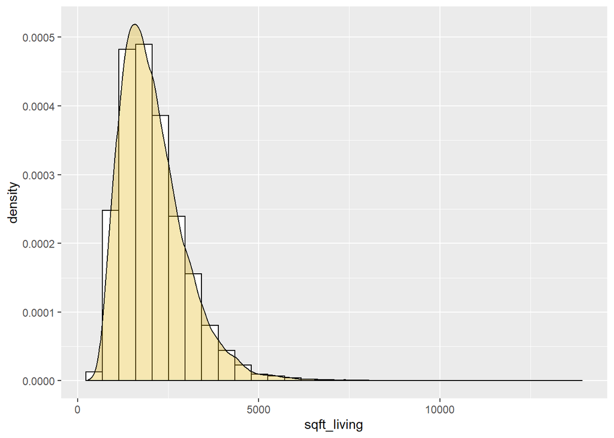

```r
options(scipen=999)
options(repr.plot.width=6, repr.plot.height=3,align="center")
ggplot(datos, aes(x=sqft_living)) + geom_histogram(aes(y=..density..), bins=30, colour="black", fill="white") + geom_density(alpha=.3, fill="#E1AF00")
```

**- Variable sqft_lot**: pies cuadrados del terreno. Es variable numérica, vamos a estudiar como se comporta:

Al igual que el precio de la vivienda, no es simétrica y los pies cudrados de las casas, están concetrados a la izquierda. Por lo que vamos a realizar una transformación logarítmica.

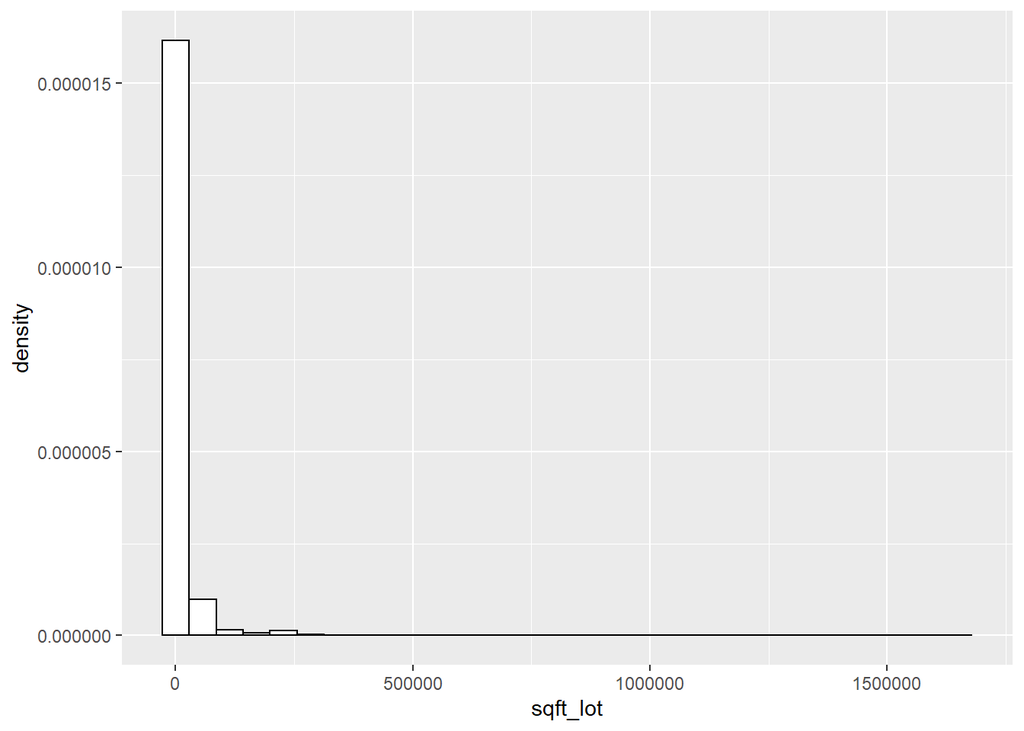

```r
ggplot(datos, aes(x=sqft_lot)) + geom_histogram(aes(y=..density..), bins=30, colour="black", fill="white")
```

**- Variable floors**: Número de plantas de la casa,hay que tener en cuenta que se contabiliza 0.5 plantas cuando una planta no tiene todo el espacio construido. (Ejem: Buhardilla). Es categórica.

```r
datos$floors<-as.factor(datos$floors)
table(datos$floors)
```

```
##
##     1   1.5     2   2.5     3   3.5
## 10680  1910  8241   161   613     8
```

**- Variable waterfront**: Es categórica.Toma valores 0 y 1 (Dummy).

- 0 = no tiene vistas al agua (Se ha confirmado este dato con la latitud y longitud de la casa en google maps.)
- 1 = tiene vistas al agua.

```r
datos$waterfront<-as.factor(datos$waterfront)
table(datos$waterfront)
```

```
##
##     0     1
## 21450   163
```

Se observa que casi todas las casas no tienen vistas al agua.

```r
table(datos$view)
```

```
##
##     0     1     2     3     4
## 19489   332   963   510   319
```

```r
datos$view <- as.factor(datos$view)
```

**- Variable condition**: Es categórica. Toma valores de 1 a 5.

```r
datos$condition <- as.factor(datos$condition)
table(datos$condition)
```

```
##
##     1     2     3     4     5
##    30   172 14031  5679  1701
```

**- Variable grade**: Es categórica. Mide la calidad de la construcción. Toma valores de 1 a 13.

```r
table(datos$grade)
```

```
##
##    1    3    4    5    6    7    8    9   10   11   12   13
##    1    3   29  242 2038 8981 6068 2615 1134  399   90   13
```

**- sqft_above** : Es numérica. Pies cuadrados por encima del suelo.

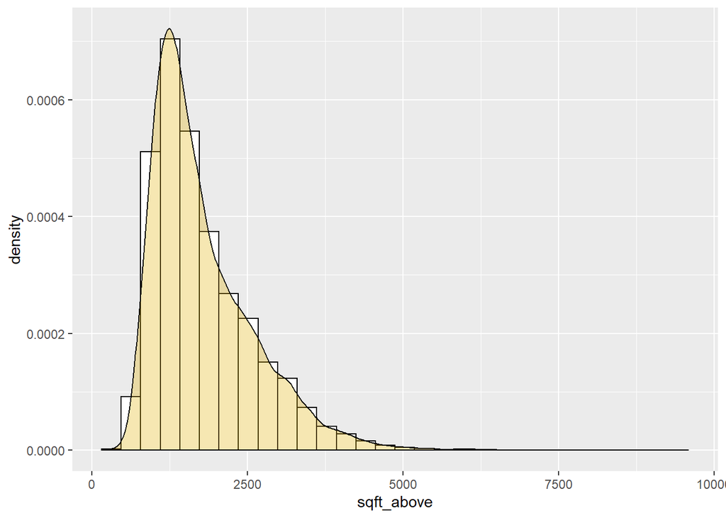

```r
options(scipen=999)
options(repr.plot.width=6, repr.plot.height=3,align="center")
ggplot(datos, aes(x=sqft_above)) + geom_histogram(aes(y=..density..), bins=30, colour="black", fill="white") + geom_density(alpha=.3, fill="#E1AF00")
```

**- yr_built** : Año de construcción de la casa. (1900-2015)

```r
table(datos$yr_built)
```

```
##
## 1900 1901 1902 1903 1904 1905 1906 1907 1908 1909 1910 1911 1912 1913 1914
##   87   29   27   46   45   74   92   65   86   94  134   73   79   59   54
## 1915 1916 1917 1918 1919 1920 1921 1922 1923 1924 1925 1926 1927 1928 1929
##   64   79   56  120   88   98   76   95   84  139  165  180  115  126  114
## 1930 1931 1932 1933 1934 1935 1936 1937 1938 1939 1940 1941 1942 1943 1944
##   90   61   38   30   21   24   40   68   52  106  156  161  223  170  140
## 1945 1946 1947 1948 1949 1950 1951 1952 1953 1954 1955 1956 1957 1958 1959
##   95  126  263  235  195  250  229  220  223  305  271  198  198  224  334
## 1960 1961 1962 1963 1964 1965 1966 1967 1968 1969 1970 1971 1972 1973 1974
##  248  224  312  256  172  187  250  350  381  280  132  104  149  149  162
## 1975 1976 1977 1978 1979 1980 1981 1982 1983 1984 1985 1986 1987 1988 1989
##  189  253  417  387  343  240  199  105  212  229  228  215  294  270  290
## 1990 1991 1992 1993 1994 1995 1996 1997 1998 1999 2000 2001 2002 2003 2004
##  320  224  198  202  249  169  195  177  239  265  218  305  222  422  433
## 2005 2006 2007 2008 2009 2010 2011 2012 2013 2014 2015
##  450  454  417  367  230  143  130  170  201  559   38
```

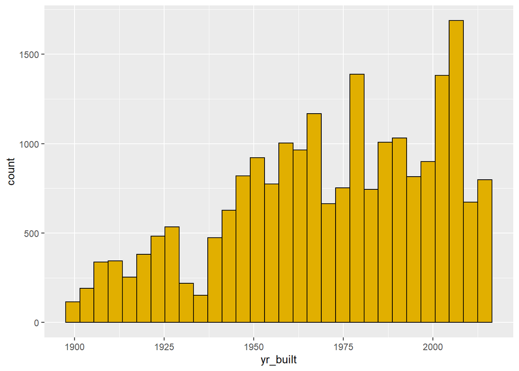

```r
options(scipen=999)
options(repr.plot.width=6, repr.plot.height=3,align="center")
ggplot(datos, aes(x=yr_built)) + geom_histogram(colour="black",bins=30, fill="#E1AF00")
```

**- Variable yr_renovates** : Año en el que la casa tuvo una ´renovación´.

```r
table(datos$yr_renovated)
```

```
##
##     0  1934  1940  1944  1945  1946  1948  1950  1951  1953  1954  1955
## 20699     1     2     1     3     2     1     2     1     3     1     3
##  1956  1957  1958  1959  1960  1962  1963  1964  1965  1967  1968  1969
##     3     3     5     1     4     2     4     5     5     2     8     4
##  1970  1971  1972  1973  1974  1975  1976  1977  1978  1979  1980  1981
##     9     2     4     5     3     6     3     8     6    10    11     5
##  1982  1983  1984  1985  1986  1987  1988  1989  1990  1991  1992  1993
##    11    18    18    17    17    18    15    22    25    20    17    19
##  1994  1995  1996  1997  1998  1999  2000  2001  2002  2003  2004  2005
##    19    16    15    15    19    17    35    19    22    36    26    35
##  2006  2007  2008  2009  2010  2011  2012  2013  2014  2015
##    24    35    18    22    18    13    11    37    91    16
```

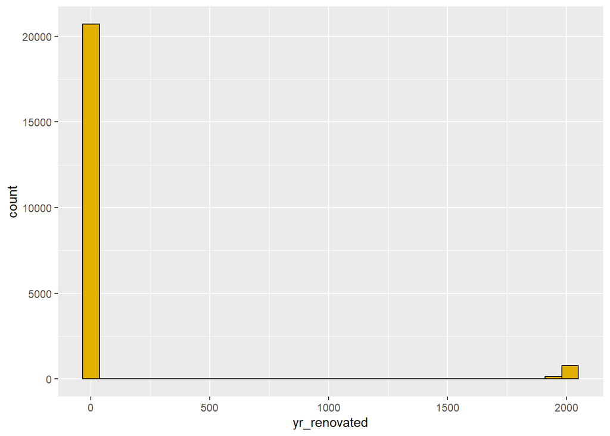

```r
options(scipen=999)
options(repr.plot.width=6, repr.plot.height=3,align="center")
ggplot(datos, aes(x=yr_renovated)) + geom_histogram(colour="black",bins=30, fill="#E1AF00")
```

Se observa que hay un año “0” y entendemos que son casas que no han tenido ningún tipo de renovación. Se podría categorizar como:

- yr_renovated = 0 , No ha tenido ninguna renovación
- yr_renovated = resto de años , Sí ha tenido renovación

**- Variable zipcode** : En qué área se encuentra la casa (Son códigos postales de Seattle). Es categórica.

```r
datos$zipcode<-as.factor(datos$zipcode)
table(datos$zipcode)
```

```
##
## 98001 98002 98003 98004 98005 98006 98007 98008 98010 98011 98014 98019
##   362   199   280   317   168   498   141   283   100   195   124   190
## 98022 98023 98024 98027 98028 98029 98030 98031 98032 98033 98034 98038
##   234   499    81   412   283   321   256   274   125   432   545   590
## 98039 98040 98042 98045 98052 98053 98055 98056 98058 98059 98065 98070
##    50   282   548   221   574   405   268   406   455   468   310   118
## 98072 98074 98075 98077 98092 98102 98103 98105 98106 98107 98108 98109
##   273   441   359   198   351   105   602   229   335   266   186   109
## 98112 98115 98116 98117 98118 98119 98122 98125 98126 98133 98136 98144
##   269   583   330   553   508   184   290   410   354   494   263   343
## 98146 98148 98155 98166 98168 98177 98178 98188 98198 98199
##   288    57   446   254   269   255   262   136   280   317
```

**- Variable sqtft_basement** : pies cuadrados del sótano. Es numérica.

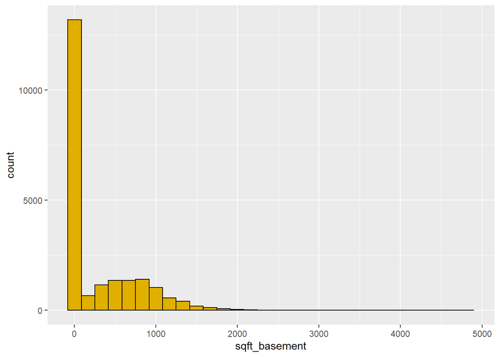

```r
options(scipen=999)
options(repr.plot.width=6, repr.plot.height=3,align="center")
ggplot(datos, aes(x=sqft_basement)) + geom_histogram(bins=30, colour="black", fill="#E1AF00")
```

Se observa que alrededor de unas 12.500 no tienen sótano, no sé si aplicar alguna transformación o se podría categorizar con casas que sí tienen sótano con casas que no tienen sótano.

A lo mejor hay que ver como se comporta con otras variables.

**- Variable lat y long** : indica la ubicación de la casa, latitud, longitud.

A lo mejor se puede dibujar una gráfica dependiendo de la zona geográfica y el precio de las casas.

**- Variable sqft_living15** : pies cuadrados de la zona habitable de la casa de los 15 vecinos más cercanos. Es numérica.

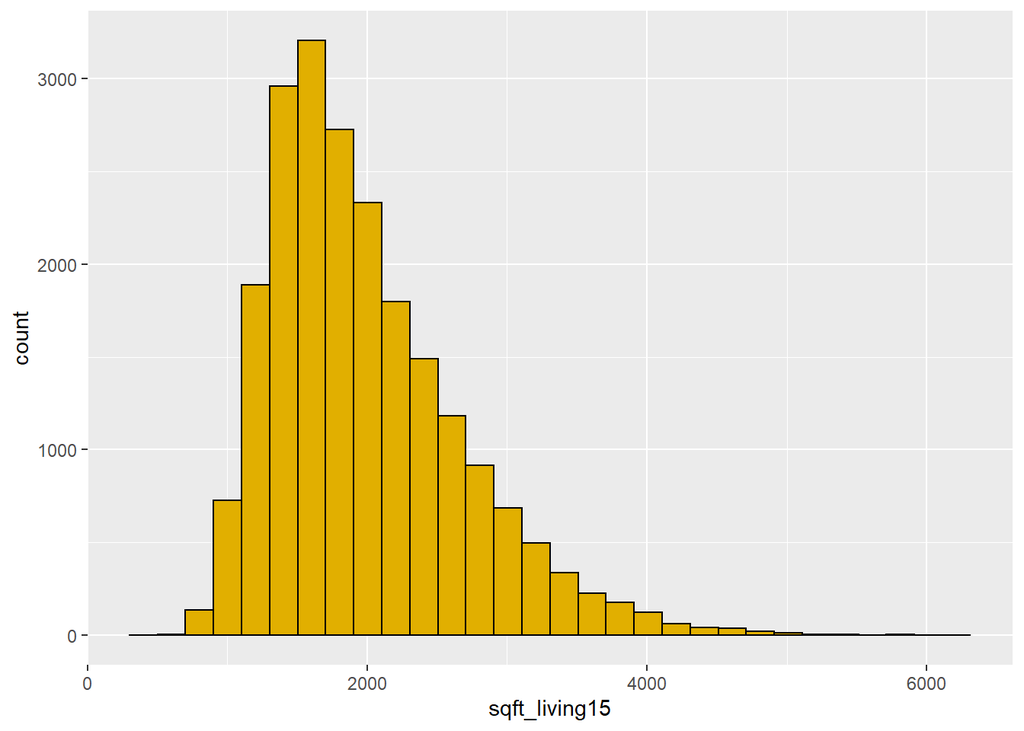

```r
options(scipen=999)
options(repr.plot.width=6, repr.plot.height=3,align="center")
ggplot(datos, aes(x=sqft_living15)) + geom_histogram(bins=30, colour="black", fill="#E1AF00")
```

```r
#tranformamos???
```

**- Variable sqft_lot15**, pies cuadrados del exterior de la casa de los 15 vecinos más cercanos.Es numérica.

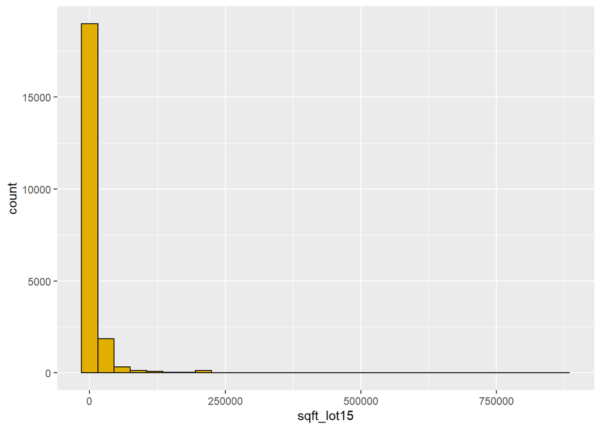

```r
options(scipen=999)
options(repr.plot.width=6, repr.plot.height=3,align="center")
ggplot(datos, aes(x=sqft_lot15)) + geom_histogram(bins=30, colour="black", fill="#E1AF00")
```

```r
#tranformamos???
```

# Train, test y validación

```r
num_total=nrow(datos)
set.seed(123456) #reproductividad

# 70% para train
indices_train = sample(1:num_total, .7*num_total)
datos_train = datos[indices_train,]

# 15% para test
indices=seq(1:num_total)
indices_test=indices[-indices_train]
indices_test1 = sample(indices_test, .15*num_total)
datos_test = datos[indices_test1,]

# 15% para validacion
indices_validacion=indices[c(-indices_train,-indices_test1)]
datos_validacion=datos[indices_validacion,]
```

# Transformación de variables cuantitativas

- Transformación Variable `price’

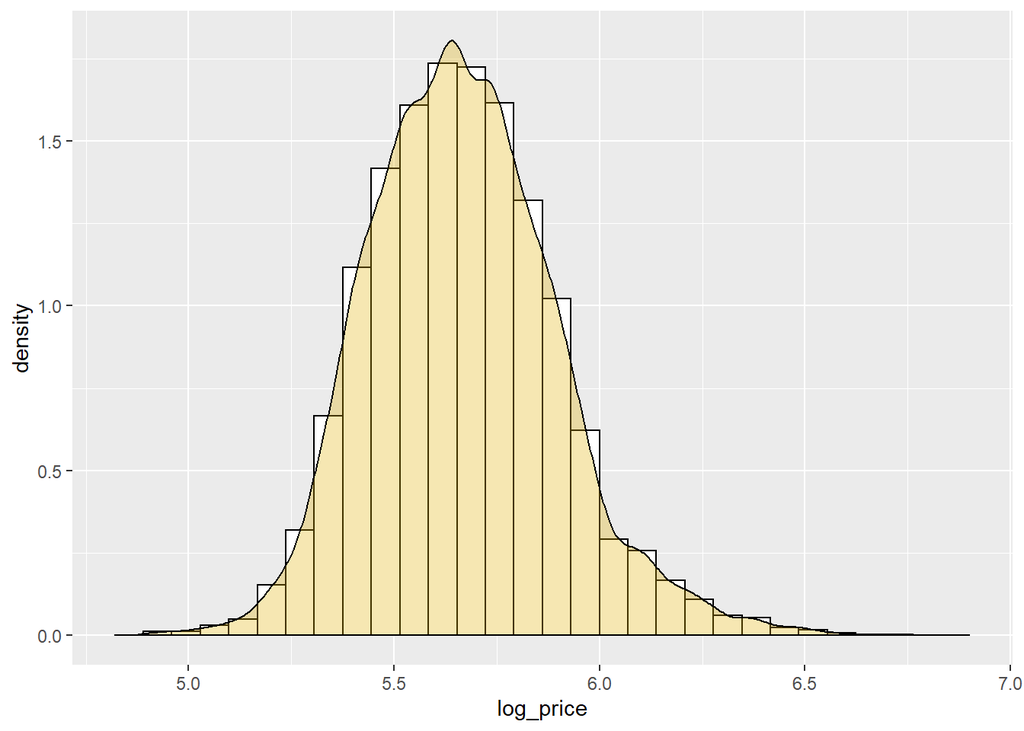

```r
datos$log_price<- log10(datos$price)

options(scipen=999)
options(repr.plot.width=6, repr.plot.height=3,align="center")
ggplot(datos, aes(x=log_price)) + geom_histogram(aes(y=..density..), bins=30, colour="black", fill="white") + geom_density(alpha=.3, fill="#E1AF00")
```

- Transformación Variable `sqft_living’

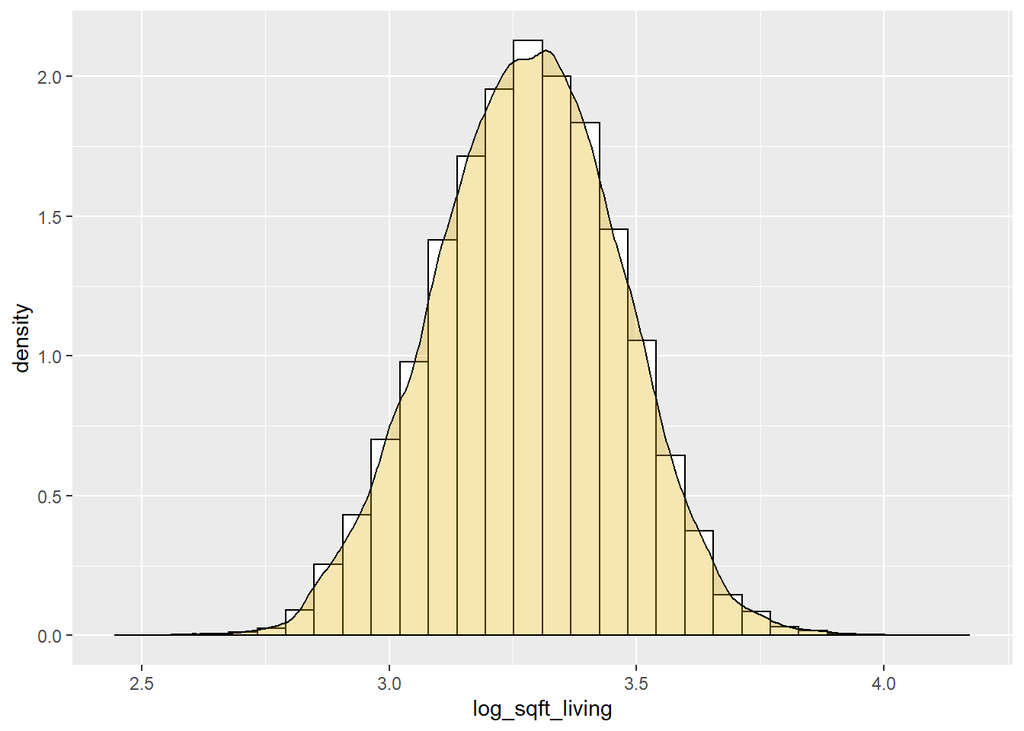

```r
datos$log_sqft_living<- log10(datos$sqft_living)

options(scipen=999)
options(repr.plot.width=6, repr.plot.height=3,align="center")
ggplot(datos, aes(x=log_sqft_living)) + geom_histogram(aes(y=..density..), bins=30, colour="black", fill="white") + geom_density(alpha=.3, fill="#E1AF00")
```

- Tranformación de la varibles ‘sqft_lot’

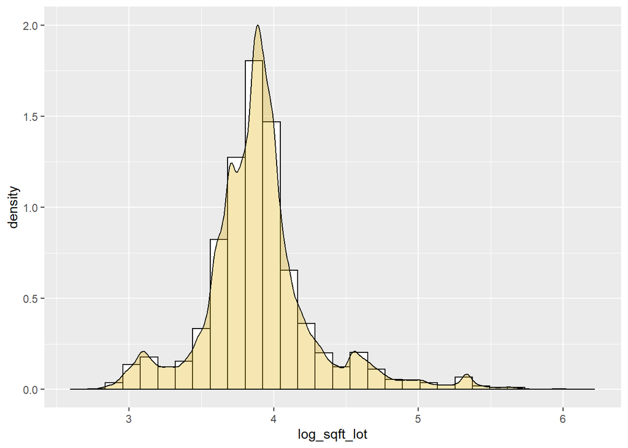

```r
#revisar si hacemos algún tipo de transformación,yo he aplicado de nuevo la logarítmica.

datos$log_sqft_lot<- log10(datos$sqft_lot)

options(scipen=999)
options(repr.plot.width=6, repr.plot.height=3,align="center")
ggplot(datos, aes(x=log_sqft_lot)) + geom_histogram(aes(y=..density..), bins=30, colour="black", fill="white") + geom_density(alpha=.3, fill="#E1AF00")
```

- Tranformación de la variable ‘sqft_above’

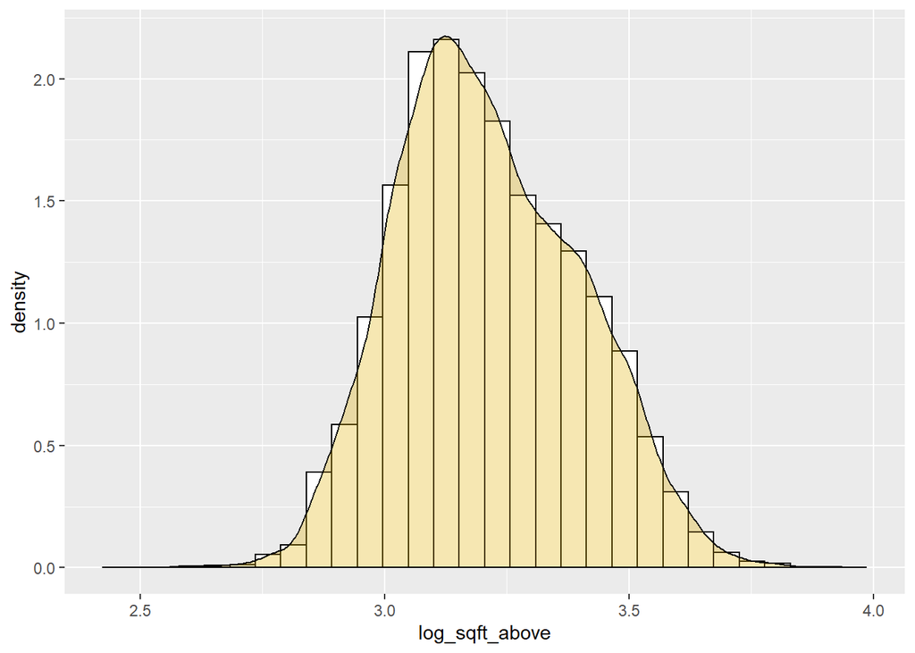

```r
#tranformamos???

datos$log_sqft_above<- log10(datos$sqft_above)

options(scipen=999)
options(repr.plot.width=6, repr.plot.height=3,align="center")
ggplot(datos, aes(x=log_sqft_above)) + geom_histogram(aes(y=..density..), bins=30, colour="black", fill="white") + geom_density(alpha=.3, fill="#E1AF00")
```

- Variable sqtft_basement
- Living15
- Lot15

# Procesado de variables cualitativas

-Bathrooms

```r
datos$bathrooms <- as.numeric(datos$bathrooms)
datos$bathrooms_categ <- cut(datos$bathrooms,breaks = c(-1,0.25,1,2,3,4,5,6,7,8),labels=c(0,1,2,3,4,5,6,7,8))

datos$bathrooms_categ <- as.factor(datos$bathrooms_categ)
table(datos$bathrooms_categ)
```

```
##
##    0    1    2    3    4    5    6    7    8
##   10 3928 6433 9365 1611  223   33    6    4
```

-Grade

Se va a volver a categorizar del siguiente modo:

```r
datos$grade<-as.numeric(datos$grade)
datos$grade_categ <- cut(datos$grade, breaks = c(1,4,9,13), labels = c(0,1,2))

table(datos$grade_categ)
```

```
##
##     0     1     2
##    32 19944  1636
```

-yr_renovated

```r
table(datos$yr_renovated)
```

```
##
##     0  1934  1940  1944  1945  1946  1948  1950  1951  1953  1954  1955
## 20699     1     2     1     3     2     1     2     1     3     1     3
##  1956  1957  1958  1959  1960  1962  1963  1964  1965  1967  1968  1969
##     3     3     5     1     4     2     4     5     5     2     8     4
##  1970  1971  1972  1973  1974  1975  1976  1977  1978  1979  1980  1981
##     9     2     4     5     3     6     3     8     6    10    11     5
##  1982  1983  1984  1985  1986  1987  1988  1989  1990  1991  1992  1993
##    11    18    18    17    17    18    15    22    25    20    17    19
##  1994  1995  1996  1997  1998  1999  2000  2001  2002  2003  2004  2005
##    19    16    15    15    19    17    35    19    22    36    26    35
##  2006  2007  2008  2009  2010  2011  2012  2013  2014  2015
##    24    35    18    22    18    13    11    37    91    16
```

```r
datos$yr_renovated_catg <-cut(datos$yr_renovated, breaks=c(-0.5,1933, 2015), labels= c("0","1"))

table(datos$yr_renovated_catg)
```

```
##
##     0     1
## 20699   914
```

# Detección, tratamiento e imputación de datos faltantes

```r
#Contar el total de NAs en la base de datos
sum(is.na(datos))
```

```
## [1] 1
```

En el caso de la variable *Bedroom* hemos visto que hay 13 casas con 0 habitaciones y una con 33. Vamos a comparar la variable número de habitaciones con los pies cuadrados habitables. Porque con un razonamiento lógico cuanto más espacio más número de habitaciones.

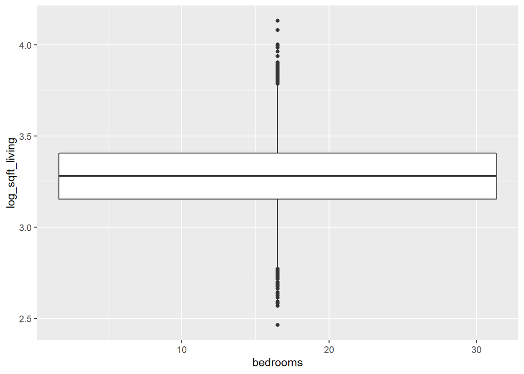

```r
ggplot(datos, aes(x=bedrooms, y=log_sqft_living, fill=bedrooms)) + geom_boxplot() + guides(fill=FALSE)
```

```r
# Para imputar los datos faltantes o erróneos ver qué técnica usar:
# datos$bedrooms[datos$bedrooms==0] = mean(datos$bedrooms)
# datos$bedrooms[datos$bedrooms==33] = mean(datos$bedrooms)
# Repasar qué técnicas usar
```

En el caso de la variable *Bathroom* hemos visto que hay 10 casas con 0 baños. Vamos a comparar la variable número de baños con los pies cuadrados habitables. Porque con un razonamiento lógico cuanto más espacio más número de baños.

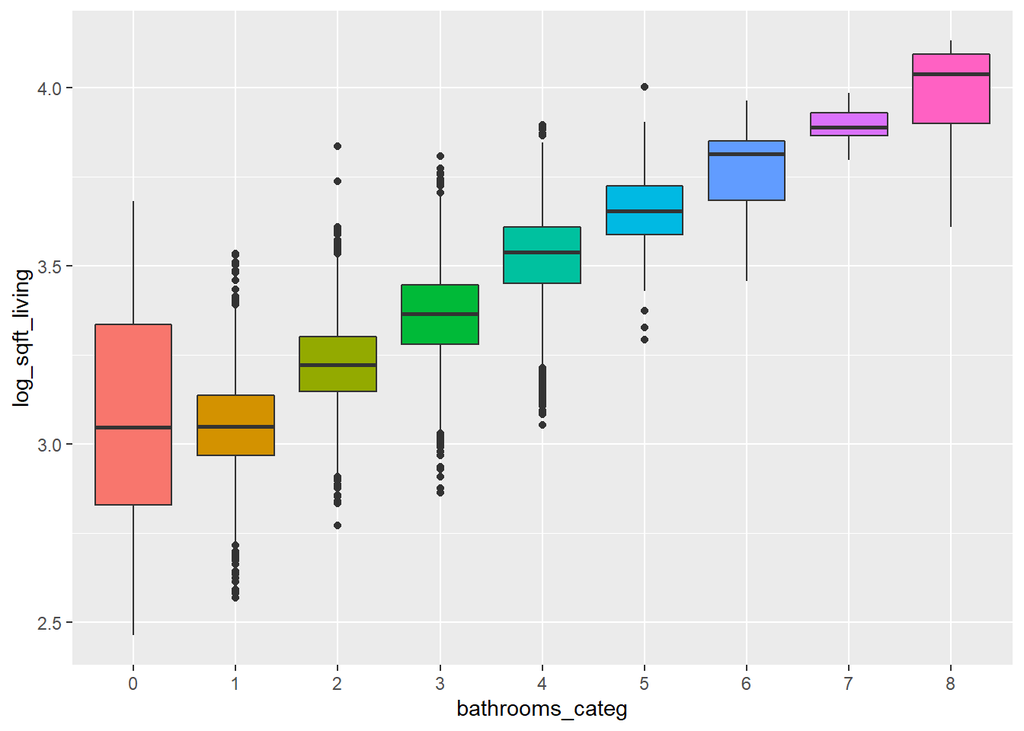

```r
ggplot(datos, aes(x=bathrooms_categ, y=log_sqft_living, fill=bathrooms_categ)) + geom_boxplot() + guides(fill=FALSE)
```

# Selección de Variables.

Para hacer una selección de variables vamos a estudiar como se comportan y si esxiste alguna relación entre ellas.

-Hacer una matriz de correlaciones, pero sólo puede hacerse con variables numéricas.

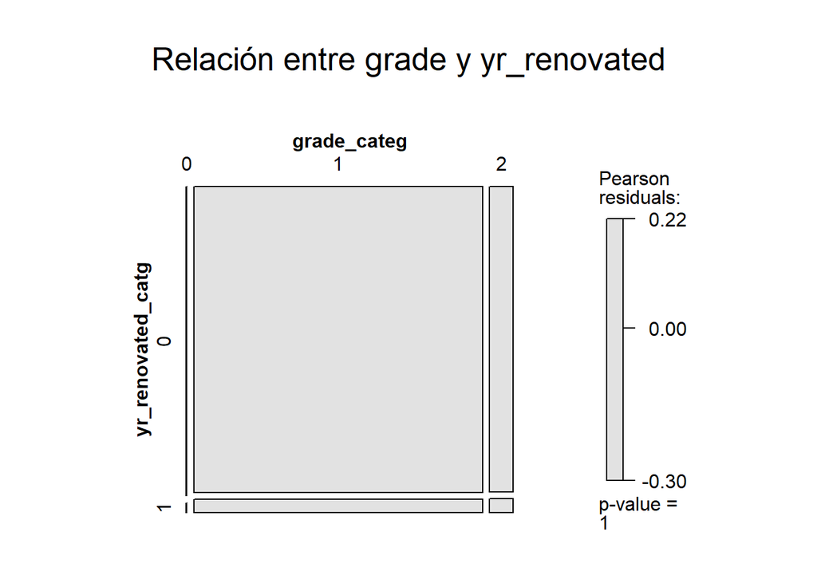

```r
# Para ver relacion entre variables categóricas ha dicho que se podrían usar tablas de contingencia o scatterplots,

art <- xtabs(~ grade_categ + yr_renovated_catg, data = datos)
mosaic(art, gp = shading_max, split_vertical = TRUE,
       main="Relación entre grade y yr_renovated")
```

```r
# Revisar qué variable meter a la matriz

#correlacion <- datos %>%  select(bedrooms, bathrooms,floors, sqft_living, sqft_lot, sqft_above, sqft_basement, waterfront, view, condition, grade, sqft_living15, sqft_lot15, lat, long, price) %>%
#cor()

#corrplot(correlacion,method="number", type="upper")
```

# Ajuste, interpretación y diagnosis del modelo de regresión lineal múltiple

# NOTAS DE LA REUNIÓN DE HOY:

- ENFRENTAR CADA VARIABLE EXPLICATIVA CON LA RESPUESTA Y VER LA RELACIÓN
- MATRIZ DE CORRELACIÓN DE LAS VARIABLES EXPLICATIVAS FRENTE A LA RESPUESTA
- UNA VEZ SELECCIONADAS LAS VARIABLES CON MAYOR RELACIÓN CON LA RESPUESTA, MIRAR LA CORRELACIÓN ENTRE ELLAS Y EN CASO DE ESTAR CORRELADAS SELECCIONAR UNA DE ELLAS Y JUSTIFICAR POR QUÉ!!!
- TRAIN AND TEST ANTES DE TODO, ANTES TRANSFORMAR Y ANTES DE VER RELACIONES (SOLO PODRIA HACERSE COMO MUCHO DESPUES DEL ANALISIS UNIVARIANTE)
- categorizar sqft-lot
- A la hora de imputar datos, no sólo borrar los registros erróneos, usar alguna otra técnica de imputación para explicarla, si no en esa parte no tendremos nota.
- Una vez transformadas las variables hay que reescarlar antes del modelo.
- Crear nuevo dataframe
- Train, test y validación